# Final Project (Hidden Code Chunks)

Justin Mai, Edrin Elmi, Sangmin Lee

2023-12-09

# Final Project: Analyzing Green House Gas Emissions and its Impact on Air Pollution and Wildfires

1. Introduction
2. Explaining the Data

Research Question 1:

- 3. Methods
- 4. Results

Research Question 2:

- 3. Methods
- 4. Results

Research Question 3:

- 3. Methods
- 4. Results
5. Discussion: What do these results mean?
6. Summary

Data:

# 1. Introduction

Context:

Since the *Industrial Age*, humans globally have increased their total greenhouse gas emissions year by year. As we reached the 2000s, we realized that these emissions are directly correlated with global warming and other unbalances in the environment.

The timeline is as follows…

1st Assessment Report of the **Intergovernmental Panel on Climate Change**, 1990, believed that climate change was due largely to natural circumstances and had little to do with human influence.

4th Assessment Report of the **IPCC**, 2007, they observed that climate change is very likely due to human actions, with evidence of an increase in average temperature and greenhouse gas concentrations released by humans.

6th Assessment Report of the **IPCC**, 2023, they have concluded that climate change is undisputedly caused by human actions and influence.

We now have glaring evidence that these abnormalities in global warming and natural effects are due to humans, so we are responsible for reversing our impact on the Earth. This is especially important to Washington residents, policymakers, and scientists because the state is largely dependent on our natural resources for food and shelter. In Washington, fisheries and shellfish harvesting is a large part of indigenous culture and residential culture. It’s also creates numerous jobs for our residents. Washington is also home to many natural sights that our residents take pride in and certainly want to preserve. Mountain range sights such as *Mount Rainer*, beaches, farms, and varying species of vegetation are all being negatively impacted due to our greenhouse emissions. Therefore, with greenhouse gas emissions impacting ocean temperatures and other abnormalities as much as atmospheric temperatures, pollution, and vegetation above water, its important to take steps to reverse these effects. The first step for many people is to understand the situation and visually seeing how we are impacting the Washington State.

To visualize our issue of excess greenhouse emissions, we will be *analyzing greenhouse gas emissions by different variables (sectors, corporation, location, time, etc.) and its impact on air pollution and wildfires*.

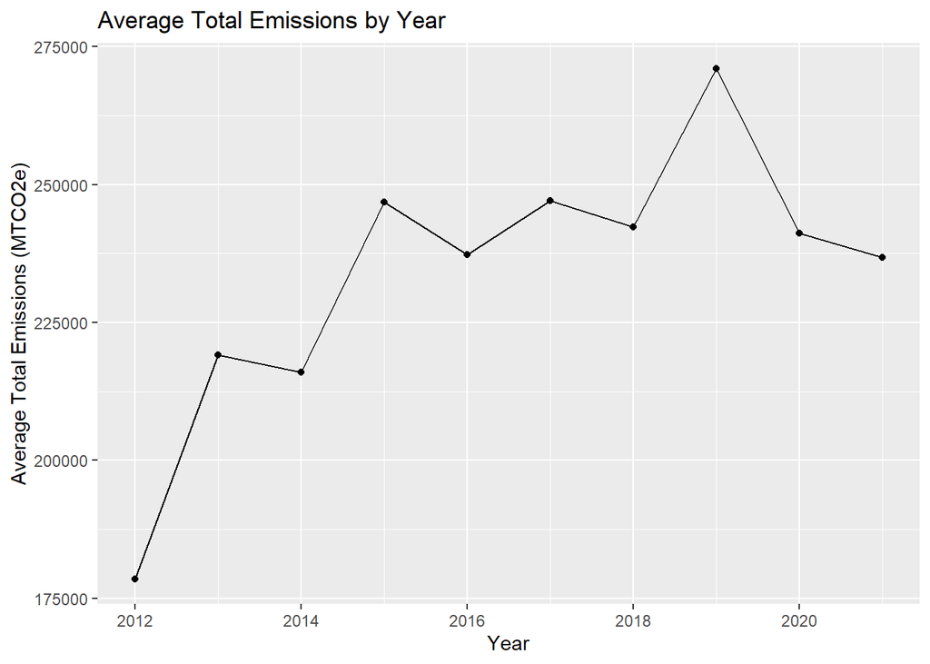

This graph demonstrates our total greenhouse gas emissions which increased from 2012 through 2019 but is moving in a decreasing trend. Even though it seems that our average total emissions is decreasing we should still be wary. One reason why is its correlation to wildfires across Washington.

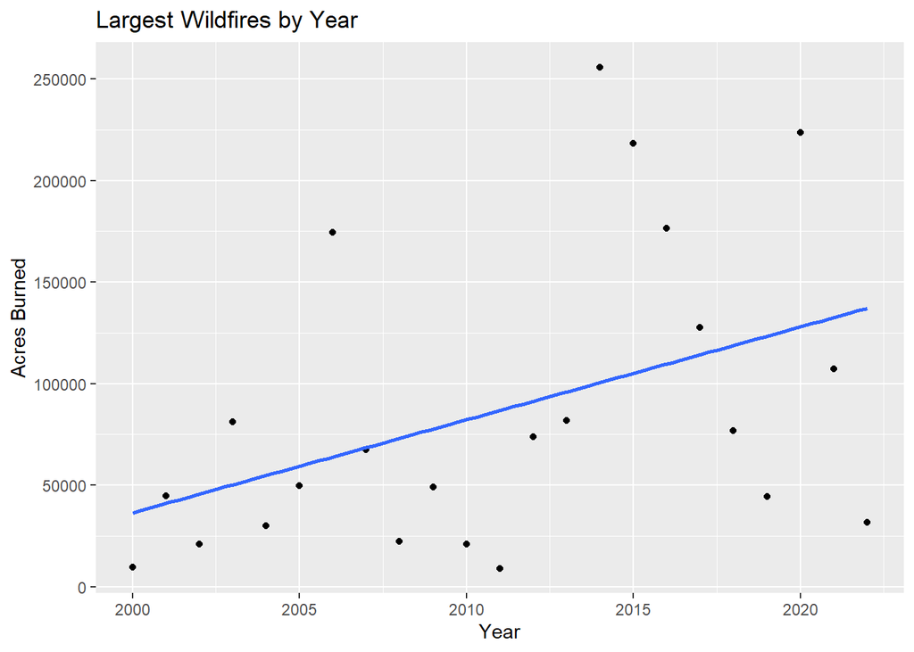

This graph demonstrates that the largest wildfires recorded in Washington state is within the recent decade more so then in the past. This correlates with our total emissions data, showing that there is a positive correlation between the two variables as time moves on. Since wildfires can impact human life and wildlife alike, we must take steps towards mitigating its effects.

We will also be looking at air pollution data which is important in impacting our way of life. We will be looking to identify a correlation between different types of GHG emissions and air pollution in Washington State throughout the years.

Beyond these introductory graphs demonstrating the importance of our topic of global emissions and its correlation to disasters today and the land of the future, we are presenting this project to further understand GHG effects and to inform our audience of Washington residents.

Some of the Research questions that we set out to answer are…

Q1 **What are the total greenhouse gas emissions based on *sector, location, and company?***

Q2 **Is there a correlation between greenhouse gas emissions and wildfire *amounts and sizes* in Washington State?**

Q3: **Is there a correlation between GHG emissions and air pollution?**

All of these research questions will help us narrow down the causes of these emissions and identify the locations that we must focus on. Narrowing down the scope by *sector, location, and/or company* is important to alleviating the issue and simplifying down the root causes and where we need to pay the most attention. We would also like to identify if the location of these emissions is related to larger wildfires. Overall, this report will give climate action groups and volunteers areas we need to focus on and demonstrate potential risks that excess emissions can cause.

# 2. Explaining the Data

```
## # A tibble: 6 × 23
##   Reporter         Year Sector Subsector `Primary NAICS Code` `NAICS Definition`
##   <chr>           <dbl> <chr>  <chr>                    <dbl> <chr>
## 1 Riverside Feed…  2020 Lives… Cattle F…               112112 Cattle Feedlots
## 2 TransAlta Cent…  2013 Power… Coal Pla…               221112 Fossil Fuel Elect…
## 3 James Hardie B…  2018 Manuf… Building…               327390 Other Concrete Pr…
## 4 WestRock CP, L…  2016 Pulp … Kraft Mi…               322130 Paperboard Mills
## 5 Bonneville Pow…  2018 Power… Electric…               221121 Electric Bulk Pow…
## 6 Puget Sound En…  2013 Power… Natural …               221112 Fossil Fuel Elect…
## # ℹ 17 more variables: `Parent Company` <chr>, City <chr>, County <chr>,
## #   Jurisdiction <chr>, `Total Emissions (MTCO2e)` <dbl>,
## #   `Biogenic Carbon Dioxide (MTCO2e)` <dbl>, `Carbon Dioxide (MTCO2e)` <dbl>,
## #   `Methane (MTCO2e)` <dbl>, `Nitrous Oxide (MTCO2e)` <dbl>,
## #   `HFCs (MTCO2e)` <dbl>, `PFCs (MTCO2e)` <dbl>,
## #   `Sulfur Hexafluoride (MTCO2e)` <dbl>, `Fluorinated - Other (MTCO2e)` <dbl>,
## #   Notes <chr>, `Point Size` <dbl>, Location <chr>, …
```

**Washington Greenhouse Gas Emission Dataset**:

**Why this Data?**: This dataset will act as our central dataset to compare with to both air pollution data and wildfire data. It was important to us that our central dataset for the story is high quality data, and we found *data.wa.gov* to be a trust worthy source. This dataset is abundant in information, giving us data for CO2 emissions, methane emissions, and many other greenhouse gas emissions that we will be looking at.

**Dataset Description**:

```
##                             Year                           Sector
##                                0                                0
##                        Subsector                 NAICS Definition
##                                0                                7
##                   Parent Company                             City
##                               71                                0
##                           County         Total Emissions (MTCO2e)
##                                0                                0
## Biogenic Carbon Dioxide (MTCO2e)          Carbon Dioxide (MTCO2e)
##                                0                                0
##                 Methane (MTCO2e)           Nitrous Oxide (MTCO2e)
##                                0                                0
```

```
## # A tibble: 6 × 12
##   OBJECTID UNITID AGENCY FIRENAME FIRENUM STARTDATE PERIMDATE  ACRES  YEAR CAUSE
##      <dbl> <chr>  <chr>  <chr>    <chr>   <chr>     <chr>      <dbl> <dbl> <chr>
## 1      450 WAGPF  "GIFF… RILEY    351     2015/07/… 2015/07/… 6.51e1  2015 LIGH…
## 2      260 WASPS  "WA D… POWERLI… 066     2012/10/… 2012/10/… 2.29e2  2012 ARSON
## 3      798 WASPA  "SPOK… FLETT L… 001282  2020/04/… 2020/04/… 1.40e2  2020 UNKN…
## 4     1288 WANEC  " "    WAGNER … 001642  2022/08/… 2022/12/… 7.59e3  2022 UNKO…
## 5      600 WACOF  "COLV… COPPER … UNKNOWN 1994/07/… 1994/07/… 1.06e4  1994 UNKN…
## 6      226 WAMSF  "MT. … SPRING   082     2009/08/… 2009/08/… 2.20e2  2009 LIGH…
## # ℹ 2 more variables: SHAPEAREA <dbl>, SHAPELEN <dbl>
```

**Washington Wildfire Data**:

This dataset originates from the *Washington Geospatial Open Data Portal*, through the website *geo.wa.gov*. This data is regularly updated and corrected by different Washington state departments. Because the Washington State Departments collected this data, it is coming from a reliable source. The Wildfire data is made for public viewing and public use without any restrictions stated in the license. This dataset consists of records of large Wildfires from 1973 to 2022 data, which is the population. We narrow down the sample to 2000-2022 data to only analyze patterns from recent times. The only data quality issue that we encountered is that many of the values from the *CAUSES* variable are *unknown*, however this isn’t an issue because we are looking at size and location of the wildfires in comparison to GHG emission patterns.

**Why this dataset?**: We are using this dataset because it is published by a trusted source that provides us data on wildfire times and size.

**Dataset Description**:

```
##    UNITID  FIRENAME   FIRENUM STARTDATE PERIMDATE     ACRES      YEAR
##         0         0         0         0         1         0         0
```

```
## # A tibble: 6 × 22
##     ...1 Date       Address      State County City  `O3 Mean` `O3 1st Max Value`
##    <dbl> <date>     <chr>        <chr> <chr>  <chr>     <dbl>              <dbl>
## 1 588647 2020-01-10 4103 BEACON… Wash… King   Seat…    0.0264              0.032
## 2 557406 2019-10-04 4103 BEACON… Wash… King   Seat…    0.0168              0.027
## 3 115639 2004-09-17 4103 BEACON… Wash… King   Seat…    0.0151              0.024
## 4 525575 2018-01-10 4103 BEACON… Wash… King   Seat…    0.0175              0.023
## 5 494954 2017-06-03 4103 BEACON… Wash… King   Seat…    0.0323              0.034
## 6  71010 2002-05-24 4103 BEACON… Wash… King   Seat…    0.0216              0.036
## # ℹ 14 more variables: `O3 1st Max Hour` <dbl>, `O3 AQI` <dbl>,
## #   `CO Mean` <dbl>, `CO 1st Max Value` <dbl>, `CO 1st Max Hour` <dbl>,
## #   `CO AQI` <dbl>, `SO2 Mean` <dbl>, `SO2 1st Max Value` <dbl>,
## #   `SO2 1st Max Hour` <dbl>, `SO2 AQI` <dbl>, `NO2 Mean` <dbl>,
## #   `NO2 1st Max Value` <dbl>, `NO2 1st Max Hour` <dbl>, `NO2 AQI` <dbl>
```

**Washington Air Pollution Data**:

We got this data off *Kaggle.com* but it is stated to be sourced by the U.S. Environmental Protection Agency (EPA). Since this is a Kaggle dataset and is published as a public dataset, it is open for all to use without any restrictions. This dataset was originally data about air pollution in the United States from 2000 to 2023, however, we filtered the data to only be on Washington state data. So, the population of this data is the United States but we are narrowing down the sample to be Washington state data. A quality issue for this data is that all of the observations are from the Greater Seattle Area instead of representing all of Seattle. However, because some of our highest emissions reside around the Seattle area, we are able to compare this data with GHG data to answer our question of correlation between GHG emissions and air pollution.

**Why this dataset?**: Because this data was sourced and used by the U.S. Environmental Protection Agency, we believe this data to be reliable and accurate to what we require to answer our research question. We also found variables such as *average ozone level, AQI, and carbon levels to be important in measuring air pollution.

**Dataset Description**:

```
##     Date    State   County     City  O3 Mean   O3 AQI  CO Mean   CO AQI
##        0        0        0        0        0        0        0        0
## SO2 Mean  SO2 AQI NO2 Mean  NO2 AQI
##        0        0        0        0
```

Each row represents data for a specific location during a specific date. We narrowed down our sample data to 3274 observations. The relevant variables would be time, location, AQI, O3, SO2, NO2 and CO data. The logistical data will be used to view correlation and the location and time data will be used to merge and clean with the other datasets. There aren’t any missing values and all of the values are reasonable (no quality issues).

# **Research Question 1: What are the total greenhouse gas emissions based on *sector, location, and company?***:

## 3. Q1 Methods

Which variables did you include, why?

- The variables I included were Sector, Parent Company, City, and Total_Emissions because the research question was based on only those variables.

**Sector** - Types of Company

**Parent Company** - Company overseeing smaller company

**City**

**Total Emissions** - Sum of all GHG emissions (CO, NO, S, etc.), in MTCO2e (metric tons of CO2 equivalent)

How did you process your data, why?

- I used group_by and summarize functions from the dplyr package to organize the information. I grouped the data by different categories like sectors, cities, and parent companies, and then added up the total greenhouse gas emissions for each group. Because it helps us see the big picture of how much greenhouse gases are being released in various areas and industries.

How did you select your sample?

- How we selected our sample was we looked for the most credibile and most resourceful dataset on greenhouse gas emissions and this dataset was the best option which is why we selected it.

Any technical decisions you did, such as either to remove missings, or replace missing values with another one?

## 4. Q1 Results

```
## # A tibble: 57 × 4
## # Groups:   Sector, City [51]
##    Sector            City           `Parent Company`            Total_Emissions
##    <chr>             <chr>          <chr>                                 <dbl>
##  1 Metals            Ferndale       Alcoa Corp.                        10053702
##  2 Metals            Kalama         <NA>                                 233702
##  3 Metals            Malaga         Alcoa Corp.                         1309513
##  4 Metals            Moses Lake     REC Silicon                          688200
##  5 Metals            Seattle        Nucor Corporation                   1045902
##  6 Metals            Spokane Valley Kaiser Aluminum Corp.               1176731
##  7 Metals            Tukwila        Jorgensen Forge Corp.                 73387
##  8 Petroleum Systems Anacortes      Air Liquide USA Inc.                 640264
##  9 Petroleum Systems Anacortes      Linde Gas North America LLC          509055
## 10 Petroleum Systems Anacortes      Marathon Petroleum Corp            13001913
## # ℹ 47 more rows
```

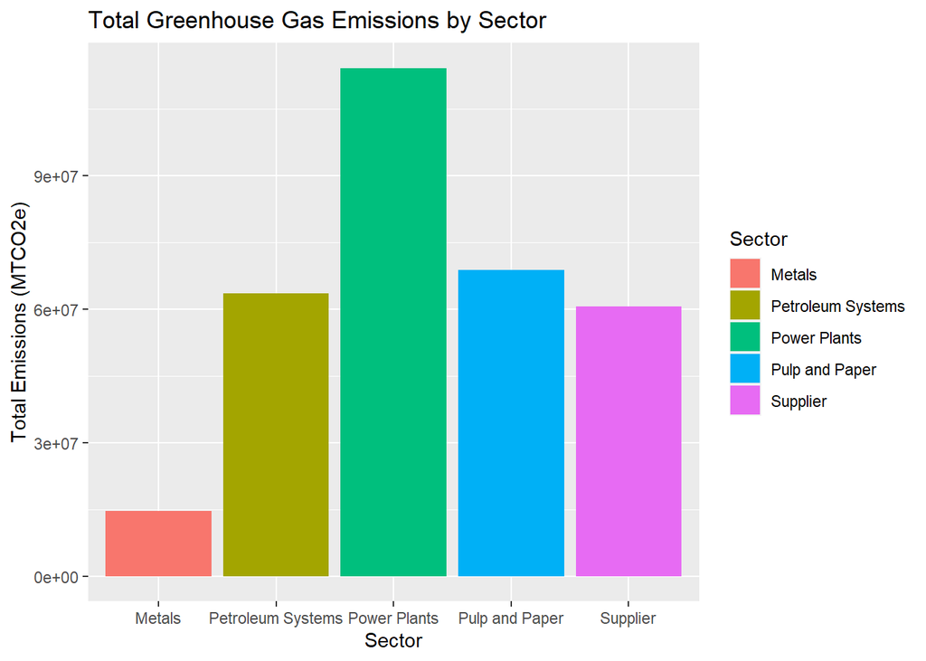

```
## # A tibble: 20 × 4
## # Groups:   Sector, City [14]
##    Sector              City      `Parent Company`                Total_Emissions
##    <chr>               <chr>     <chr>                                     <dbl>
##  1 Chemicals           Longview  Solvay Chemicals Inc.                    481547
##  2 Metals              Ferndale  Alcoa Corp.                            10053702
##  3 Natural Gas Systems Bellevue  Puget Holdings LLC                       602466
##  4 Petroleum Systems   Anacortes Air Liquide USA Inc.                     640264
##  5 Petroleum Systems   Anacortes Linde Gas North America LLC              509055
##  6 Petroleum Systems   Anacortes Marathon Petroleum Corp                13001913
##  7 Petroleum Systems   Anacortes Shell Petroleum Inc.                   19235767
##  8 Petroleum Systems   Ferndale  Phillips 66 Company                     7880228
##  9 Power Plants        Bellevue  Puget Holdings LLC                        21055
## 10 Power Plants        Centralia <NA>                                   59338269
## 11 Power Plants        Ferndale  Puget Holdings LLC                      3781208
## 12 Power Plants        Longview  Puget Holdings LLC                      5784628
## 13 Pulp and Paper      Longview  Kapstone Paper & Packaging Cor…        16317134
## 14 Pulp and Paper      Longview  NP Paper Investor Holdings LLC           394474
## 15 Pulp and Paper      Longview  Weyerhaeuser Co.                       15779251
## 16 Supplier            Bellevue  Puget Holdings LLC                     37504945
## 17 Waste               Longview  Cowlitz County                           167364
## 18 Wood Products       Centralia Littlejohn & Co. LLC                     113780
## 19 Wood Products       Centralia Sierra Pacific Industries                445694
## 20 Wood Products       Longview  American Industrial Partners (…          136581
```

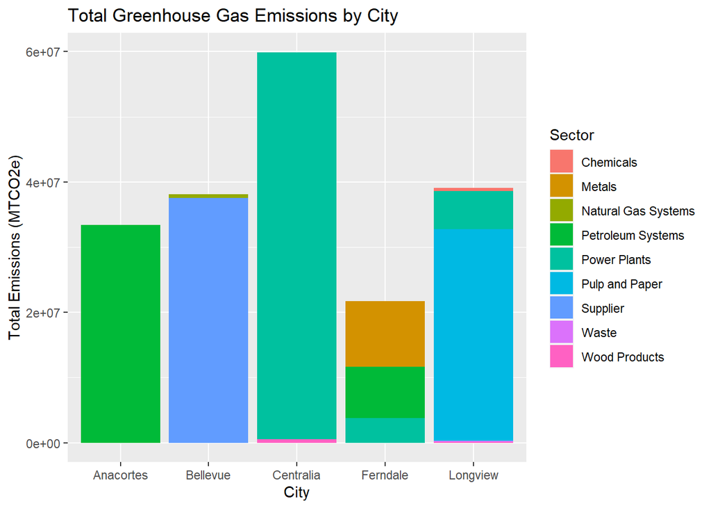

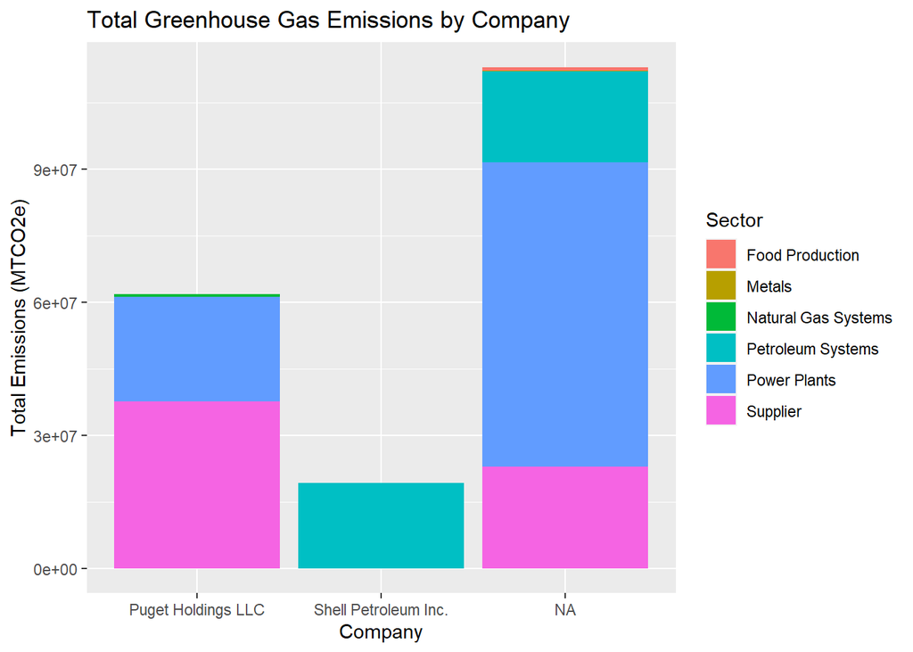

# **Research question 2. Is there a correlation between greenhouse gas emissions and wildfire *amounts and sizes* in Washington State?**

## 3. Q2 Methods

Variables Include in final dataset (**merged_data**)

**YEAR**

**avg_size** - Average wildfire size (in acres) by year

**Wildfires_count** - Number of wildfires for that year

**Total Emissions** - Sum of all GHG emissions (CO, NO, S, etc.), in MTCO2e (metric tons of CO2 equivalent)

- We created **avg_size** and **Wildfires_count** to help us compare the results to **Total Emissions**, analyzing if there’s a correlation or not.
- We processed the data by first using group_by() and summarize() functions to get the **avg_size**, **Wildfires_count**, and **Total Emissions**. We then joined the wildfire and GHG emissions data together using right_join().
- We selected our sample by grouping our data by year.
- We didn’t make any technical decisions to replace NA’s
- We used line graphs to represent the pattern of each graph, giving us a clear visual of increasing and decrasing patterns.

## 4. Q2 Results

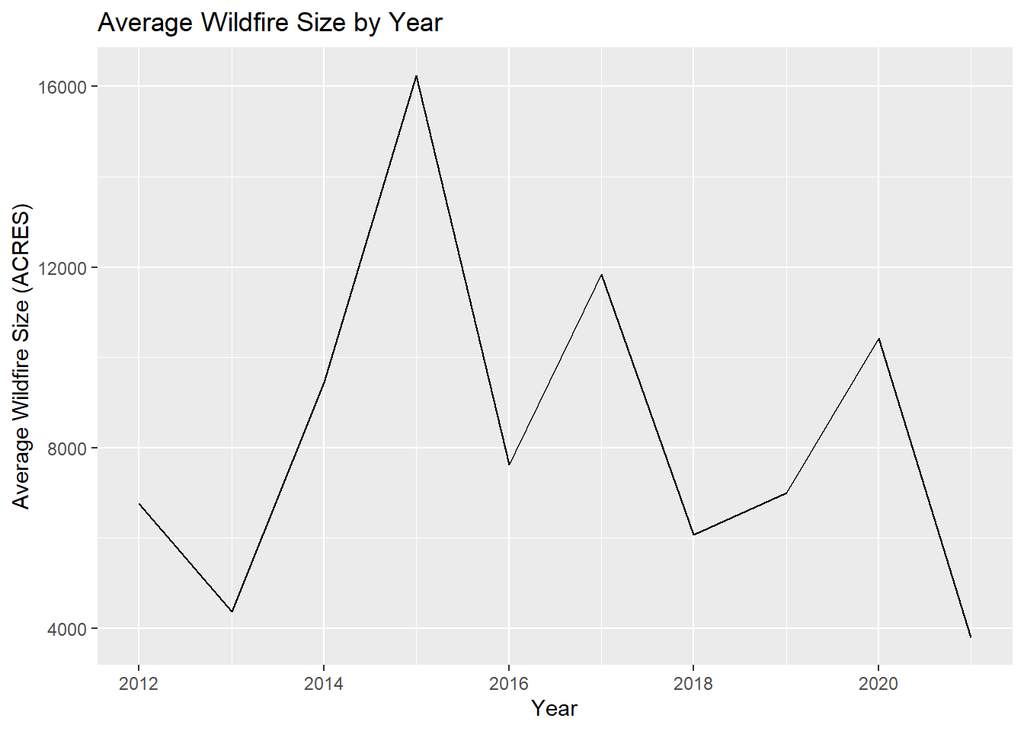

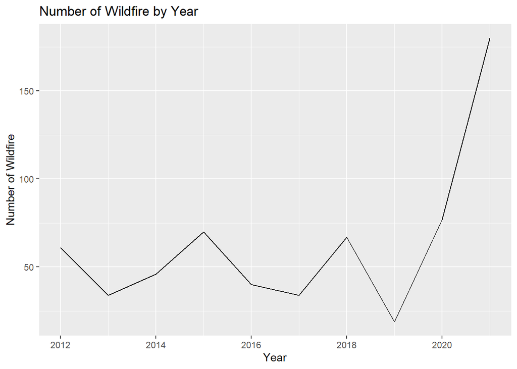

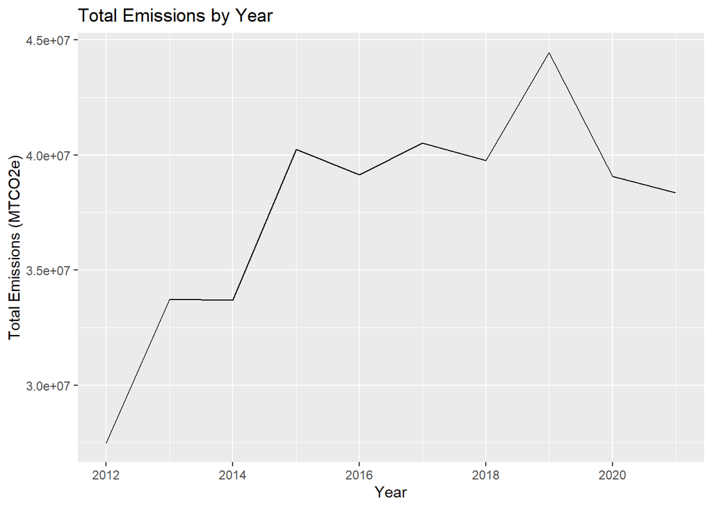

The total emissions had increased since 2012 to 2019, and has decreased since 2019 to the presemt.

Correlation between the number of wildfires and the total gas emissions. Examining the second and third graphs, they exhibit contrasting characteristics.While the number of wildfires is rapidly increasing from 2019, the total gas emissions has decreased from 2019.

# **Research Question 3: Is there a correlation between GHG emissions and air pollution?**

## 3. Q3 Methods

To answer my question I used *dplyr* functions to merge and reshape my data. I used the **Washington GHG Emissions** data and the **United States Air Pollution** data. An issue that I would like to note is that after I filtered the Air Pollution data to Washington state only, I found that the dataset only considered Seattle air pollution. Because there weren’t any better dataset available, I made due by filtering my Washington GHG Data to the *King County* area to highlight the Greater Seattle Area. This will allow me to compare the two data since all the sectors are now around the same area and could possible impact Air pollution in Seattle.

I first selected the logistical data that I need from the GHG data and got the averages for all the variables by year to prepare for merging and reshaping.

```
## # A tibble: 6 × 7
##   Year  `Total Emissions (MTCO2e)` Biogenic Carbon Diox…¹ Carbon Dioxide (MTCO…²
##   <chr>                      <dbl>                  <dbl>                  <dbl>
## 1 2012                      58312.                  1392.                 47792.
## 2 2013                      60827.                  2315.                 51220.
## 3 2014                      71392.                  2918.                 61072.
## 4 2015                     293849.                  1550.                285172.
## 5 2016                     307510.                  1368.                298948.
## 6 2017                     355963.                  1412.                347190.
## # ℹ abbreviated names: ¹`Biogenic Carbon Dioxide (MTCO2e)`,
## #   ²`Carbon Dioxide (MTCO2e)`
## # ℹ 3 more variables: `Methane (MTCO2e)` <dbl>, `Nitrous Oxide (MTCO2e)` <dbl>,
## #   County <chr>
```

I then formatted the Air pollution data to year only so I can merge it by year with the GHG data. I also summarized the averages for all values by the year.

```
## # A tibble: 6 × 9
##   Year  `O3 Mean` `O3 AQI` `CO Mean` `CO AQI` `SO2 Mean` `SO2 AQI` `NO2 Mean`
##   <chr>     <dbl>    <dbl>     <dbl>    <dbl>      <dbl>     <dbl>      <dbl>
## 1 2000     0.0189     24.2     0.358     5.65       2.99      12.7       18.0
## 2 2001     0.0183     24.1     0.310     5.07       3.79      14.6       17.5
## 3 2002     0.0202     25.8     0.298     4.95       2.66      12.9       17.9
## 4 2003     0.0234     29.4     0.345     5.30       2.63      12.8       16.9
## 5 2004     0.0209     26.3     0.528     7.31       3.02      12.2       16.0
## 6 2005     0.0182     23.3     0.555     7.58       2.99      12.9       15.5
## # ℹ 1 more variable: `NO2 AQI` <dbl>
```

I then joined the two datasets by year to get and idea of what all of their variables and values look like together.

```
## # A tibble: 6 × 15
##   Year  `Total Emissions (MTCO2e)` Biogenic Carbon Diox…¹ Carbon Dioxide (MTCO…²
##   <chr>                      <dbl>                  <dbl>                  <dbl>
## 1 2013                      60827.                  2315.                 51220.
## 2 2014                      71392.                  2918.                 61072.
## 3 2015                     293849.                  1550.                285172.
## 4 2016                     307510.                  1368.                298948.
## 5 2017                     355963.                  1412.                347190.
## 6 2018                     361356.                  1514.                352301.
## # ℹ abbreviated names: ¹`Biogenic Carbon Dioxide (MTCO2e)`,
## #   ²`Carbon Dioxide (MTCO2e)`
## # ℹ 11 more variables: `Methane (MTCO2e)` <dbl>,
## #   `Nitrous Oxide (MTCO2e)` <dbl>, County <chr>, `O3 Mean` <dbl>,
## #   `O3 AQI` <dbl>, `CO Mean` <dbl>, `CO AQI` <dbl>, `SO2 Mean` <dbl>,
## #   `SO2 AQI` <dbl>, `NO2 Mean` <dbl>, `NO2 AQI` <dbl>
```

Variables included for final dataset (**ap_ghg_3**):

**Year**

**Total Emissions** - Sum of all GHG emissions (CO, NO, S, etc.), in MTCO2e (metric tons of CO2 equivalent)

**Biogenic Carbon Dioxide (MTCO2e)**

**Carbon Dioxide (MTCO2e)**

**Methane (MTCO2e)**

**Nitrous Oxide (MTCO2e)**

**County** - Only used King County Data

**O3 Mean** - Average Ozone level for a day per year.

**O3 AQI** - Average Air Quality Index for Ozone per year

**CO Mean** - Average Carbon Monoxide level for a day per year.

**CO AQI** - Average Air Quality Index for Carbon Monoxide per year

**SO2 Mean** - Average Sulphur Dioxide level a day per year

**SO2 AQI** - Average Air Quality Index for Sulphur Dioxide per year

**NO2 Mean** - Average Nitrogen Dioxide level a day per year

**NO2 AQI** - Average Air Quality Index for Nitrogen Dioxide per year

Even though some variables are more relevant than others, I chose to incorporate all these variables so I can show the individual trends for each, giving a more accurate depiction when comparing GHG emissions and air pollution/AQI.

To create the graphs, I then pivoted both the Air pollution and GHG datasets to long form, making it easier to sort the points by the variables I want. For the GHG emissions data, I removed all of the non-numeric variables except for county because it isn’t needed when comparing general air pollution in Seattle. For the Air Pollution data I also only kept the numeric data that I needed to graph *AQI values* and *Average Gas Levels* (which is the average of the mean gas levels per day).

To summarize, all this preparation will be used to create various line plots that compares different factors of GHG emissions to air quality and air pollution data. I selected my sample by making sure that data in both datasets are comparable to each other, so it was important for me to narrow down the scope of location and time. I also didn’t use any complex statistical methods, just graphed my data using color-cordinated line plots to demonstrate patterns.

## 4. Q3 Results

```
## # A tibble: 9 × 15
##   Year  `Total Emissions (MTCO2e)` Biogenic Carbon Diox…¹ Carbon Dioxide (MTCO…²
##   <chr>                      <dbl>                  <dbl>                  <dbl>
## 1 2013                      60827.                  2315.                 51220.
## 2 2014                      71392.                  2918.                 61072.
## 3 2015                     293849.                  1550.                285172.
## 4 2016                     307510.                  1368.                298948.
## 5 2017                     355963.                  1412.                347190.
## 6 2018                     361356.                  1514.                352301.
## 7 2019                     367291.                  1437                 358041.
## 8 2020                     374389.                  1310.                361258.
## 9 2021                     398349.                  1164.                378650.
## # ℹ abbreviated names: ¹`Biogenic Carbon Dioxide (MTCO2e)`,
## #   ²`Carbon Dioxide (MTCO2e)`
## # ℹ 11 more variables: `Methane (MTCO2e)` <dbl>,
## #   `Nitrous Oxide (MTCO2e)` <dbl>, County <chr>, `O3 Mean` <dbl>,
## #   `O3 AQI` <dbl>, `CO Mean` <dbl>, `CO AQI` <dbl>, `SO2 Mean` <dbl>,
## #   `SO2 AQI` <dbl>, `NO2 Mean` <dbl>, `NO2 AQI` <dbl>
```

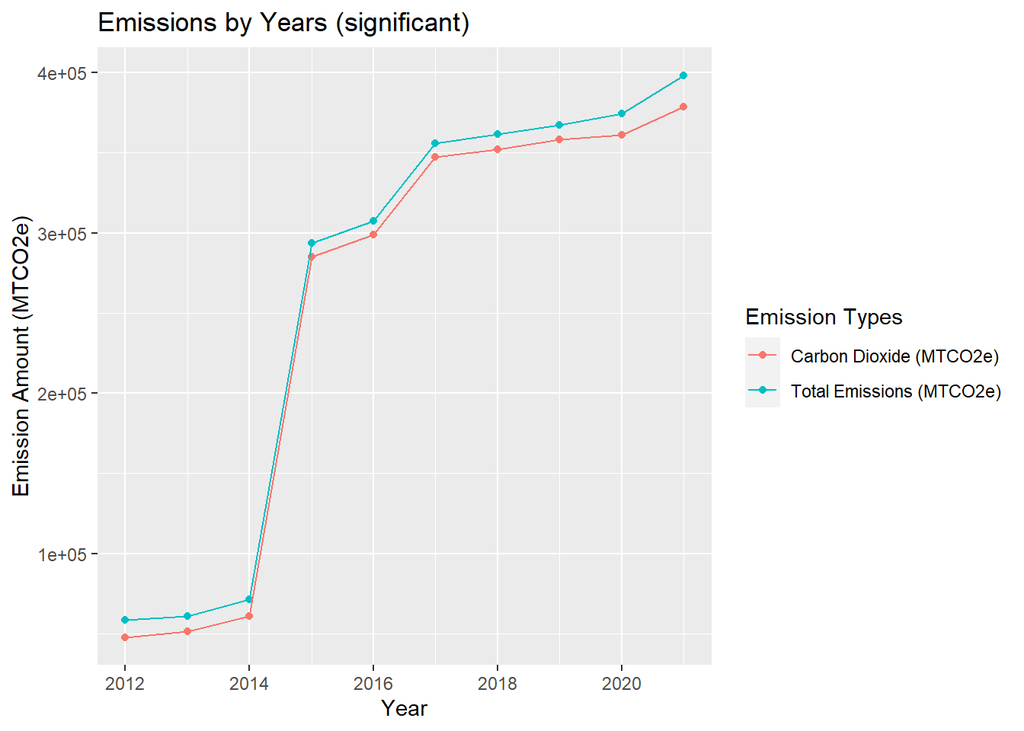

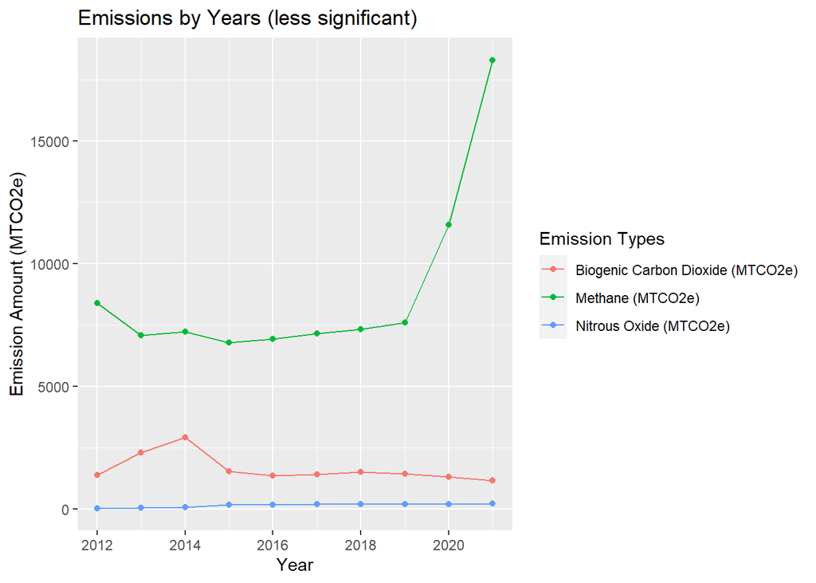

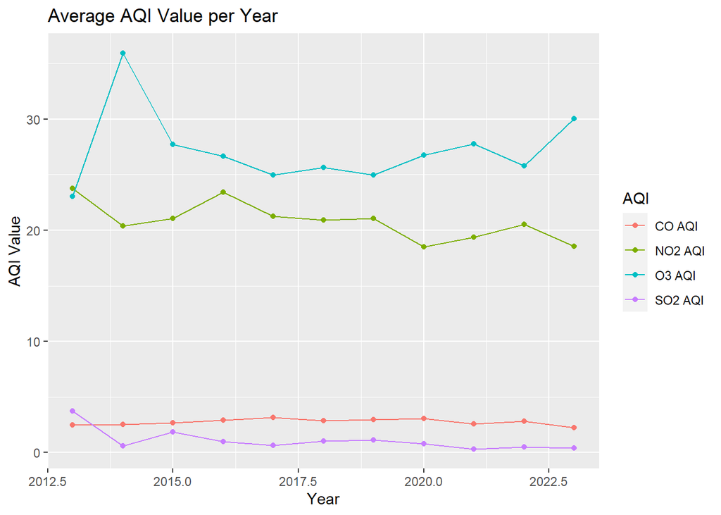

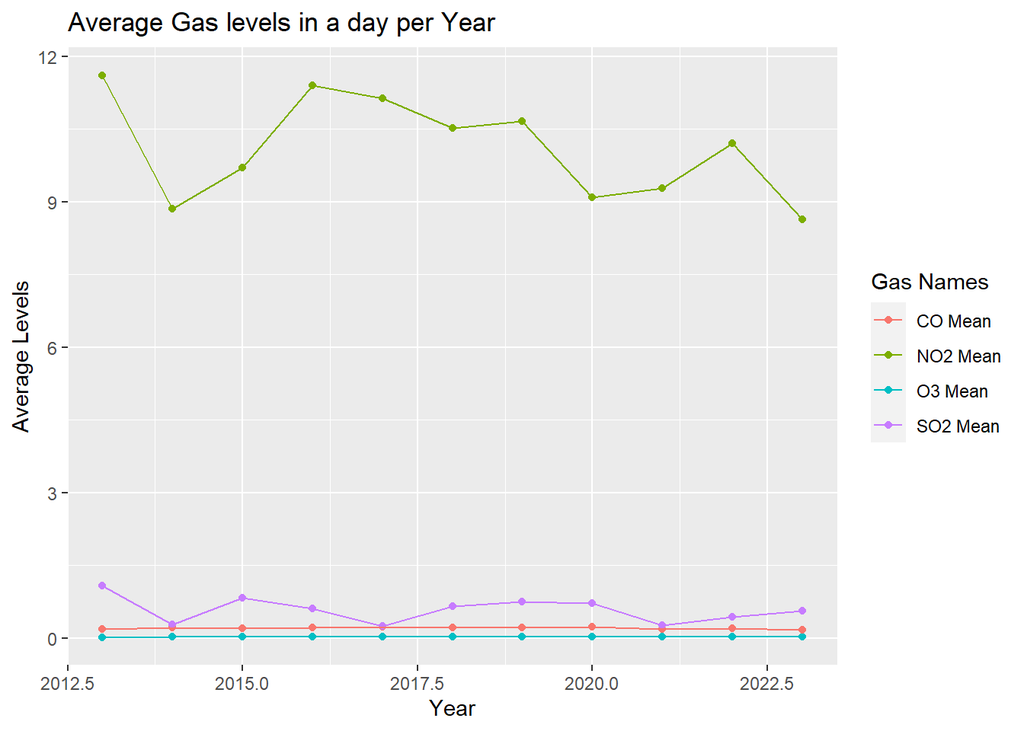